# MPDW simulasi minggu 4

Rafi AKbar Wibawa

2023-09-21

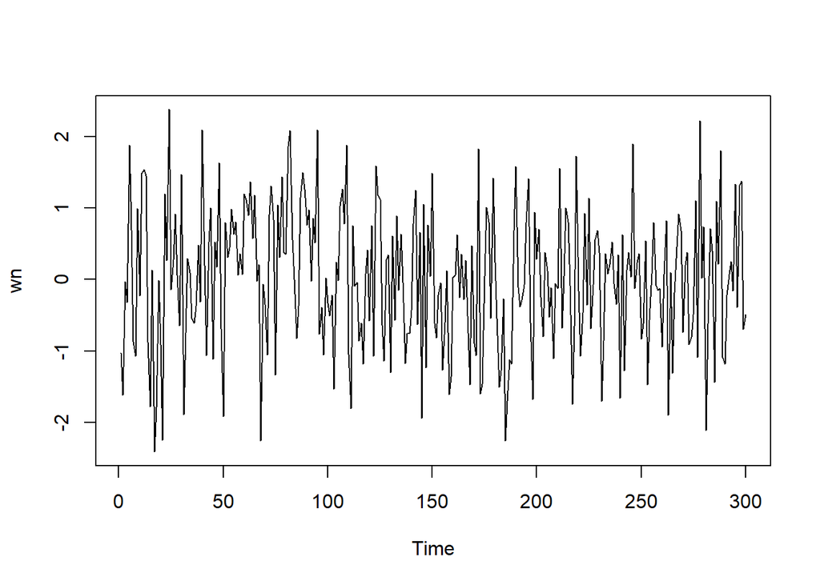

```r
set.seed(095)
wn <- rnorm(300)
ts.plot(wn)
```

```r
set.seed(095)
ma <- wn[c(1,2)]
```

##Pembangkitan Data MA(2) dengan theta 1 = 0.4 dan theta 2 = 0.6 secara manual

```r
for(i in 3:300){
   ma[i] <- wn[i] + 0.4 * wn[i - 1] + 0.6 * wn[i - 2]
}
ma
```

```
##   [1] -1.0291204016 -1.6155257834 -1.2915620329 -1.3015948799  1.7351926068
##   [6]  1.2562788568  0.5420682960 -1.0027522032  0.0455317307 -0.4772123823
##  [11]  1.9910489964  1.9896849554  2.9592939874  0.6274382561 -1.2542519075
##  [16] -1.1064519824 -3.4259027876 -2.6702081443 -2.1772598343 -1.9861737339
##  [21] -2.6256484014 -0.2506699113 -0.6026656155  3.2031114027  0.9706535444
##  [26]  1.6468681019  0.9395637722  0.5932560689 -0.0726194407  1.2487531452
##  [31] -1.6874269623 -0.6176209397 -1.1359621756 -0.2292622776 -0.3224219002
##  [36] -0.7697074251 -0.9383012926 -0.0388244474 -0.3398652534  2.2529335638
##  [41]  0.8528729667  0.2692343578  0.2166905557  0.5705335244 -0.3984528099
##  [46]  0.6760583981 -0.2820924818  2.0133111506  0.0704816091 -1.2108088641
##  [51] -0.3858233765 -0.5245111947  1.0459147593  1.3451629886  1.2947874820
##  [56]  1.6426166974  0.7663716670  0.8645058603  0.2521133726  1.4401773026
##  [61]  1.6417561109  2.0642858034  2.3976502479  1.6626357876  2.2267088355
##  [66]  0.7941777120  0.9024398131 -2.1907846412 -0.8432159110 -1.7305392767
##  [71] -1.2358974650  0.2723339928  1.0309009367  1.9033543294 -0.2192564424
```

[output cut: 45 more lines]

##Pembangkitan Data MA(2) dengan theta 1 = 0.4 dan theta 2 = 0.6 secara otomatis

```r
set.seed(095)
ma1 <- arima.sim(list(order=c(0,0,2), ma = c(0.4,0.6)), n=300)
ma1
```

```
## Time Series:
## Start = 1
## End = 300
## Frequency = 1
##   [1] -1.2915620329 -1.3015948799  1.7351926068  1.2562788568  0.5420682960
##   [6] -1.0027522032  0.0455317307 -0.4772123823  1.9910489964  1.9896849554
##  [11]  2.9592939874  0.6274382561 -1.2542519075 -1.1064519824 -3.4259027876
##  [16] -2.6702081443 -2.1772598343 -1.9861737339 -2.6256484014 -0.2506699113
##  [21] -0.6026656155  3.2031114027  0.9706535444  1.6468681019  0.9395637722
##  [26]  0.5932560689 -0.0726194407  1.2487531452 -1.6874269623 -0.6176209397
##  [31] -1.1359621756 -0.2292622776 -0.3224219002 -0.7697074251 -0.9383012926
##  [36] -0.0388244474 -0.3398652534  2.2529335638  0.8528729667  0.2692343578
##  [41]  0.2166905557  0.5705335244 -0.3984528099  0.6760583981 -0.2820924818
##  [46]  2.0133111506  0.0704816091 -1.2108088641 -0.3858233765 -0.5245111947
##  [51]  1.0459147593  1.3451629886  1.2947874820  1.6426166974  0.7663716670
```

[output cut: 49 more lines]

## Karakteristik MA(2)

### Plot Time Series

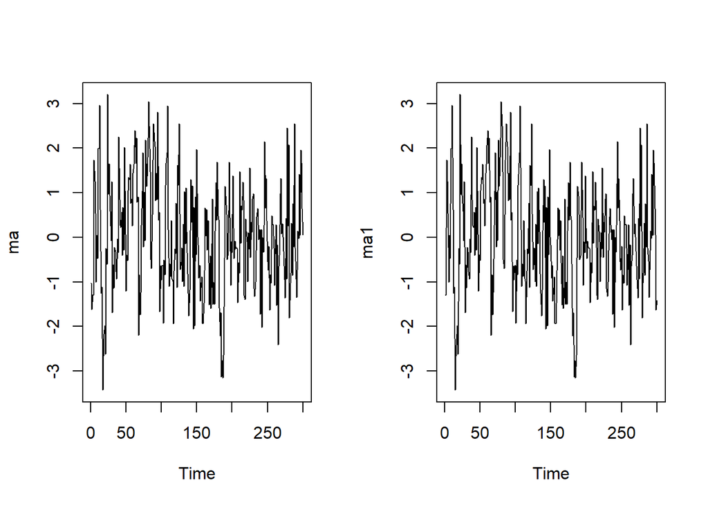

```r
par(mfrow = c(1,2))
ts.plot(ma)
ts.plot(ma1)
```

### Plot ACF

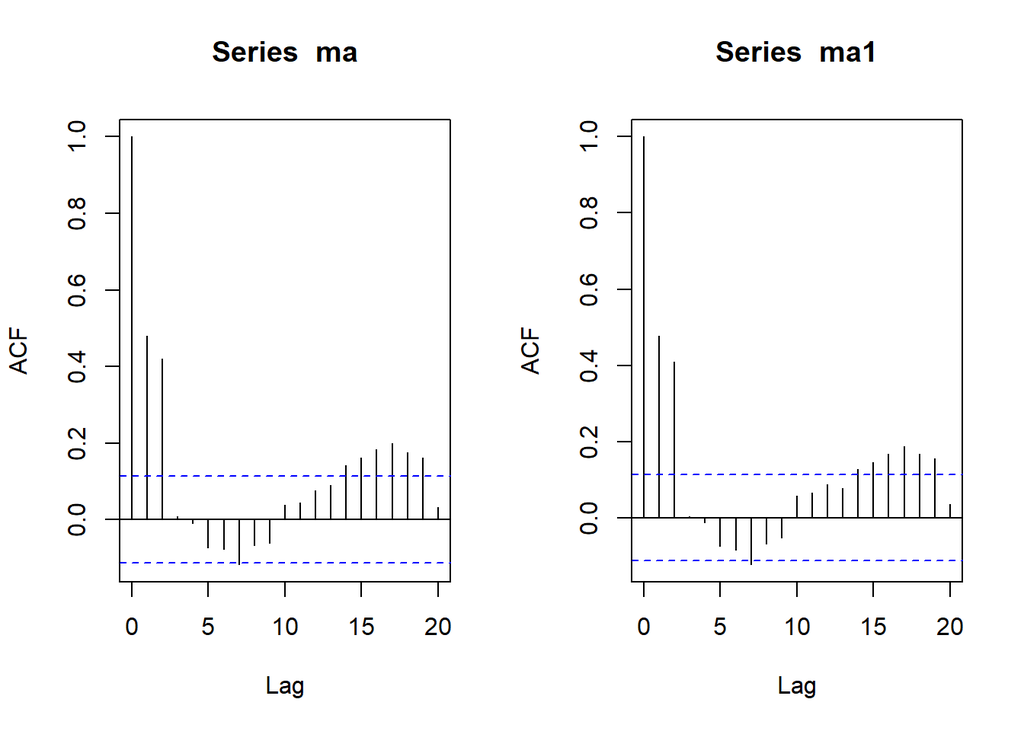

```r
par(mfrow = c(1,2))
acf(ma,lag.max = 20)
acf(ma1,lag.max = 20)
```

### Plot PACF

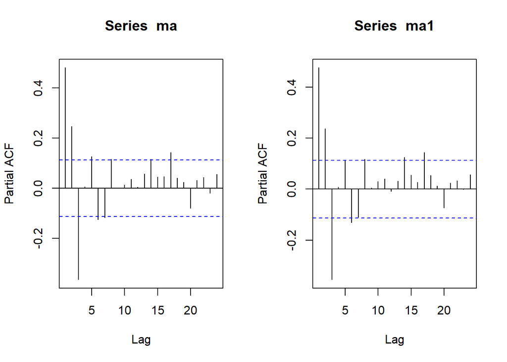

```r
par(mfrow = c(1,2))
pacf(ma)
pacf(ma1)
```

Berdasarkan plot PACF tersebut, terlihat bahwa plot PACF cenderung *tails off* dan membentuk gelombang sinus

### Plot EACF

```r
library(TSA)
```

```r
par(mfrow = c(1,2))
eacf(ma)
```

```
## AR/MA
##   0 1 2 3 4 5 6 7 8 9 10 11 12 13
## 0 x x o o o o x o o o o  o  o  x
## 1 x x x o o o o o o o o  o  o  o
## 2 x x o o o o o o o o o  o  o  o
## 3 o x x o x o o o o o o  o  o  o
## 4 o x x o x o o o o o o  o  o  o
## 5 x x x x x x o o o o o  o  o  o
## 6 x x x o x o o o o o o  o  o  o
## 7 x x x x x x x o o o o  o  o  o
```

```r
eacf(ma)
```

```
## AR/MA
##   0 1 2 3 4 5 6 7 8 9 10 11 12 13
## 0 x x o o o o x o o o o  o  o  x
## 1 x x x o o o o o o o o  o  o  o
## 2 x x o o o o o o o o o  o  o  o
## 3 o x x o x o o o o o o  o  o  o
## 4 o x x o x o o o o o o  o  o  o
## 5 x x x x x x o o o o o  o  o  o
## 6 x x x o x o o o o o o  o  o  o
## 7 x x x x x x x o o o o  o  o  o
```

##Plot data lag

```r
#Yt
yt_ma <- ma[-1]
yt_ma
```

```
##   [1] -1.6155257834 -1.2915620329 -1.3015948799  1.7351926068  1.2562788568
##   [6]  0.5420682960 -1.0027522032  0.0455317307 -0.4772123823  1.9910489964
##  [11]  1.9896849554  2.9592939874  0.6274382561 -1.2542519075 -1.1064519824
##  [16] -3.4259027876 -2.6702081443 -2.1772598343 -1.9861737339 -2.6256484014
##  [21] -0.2506699113 -0.6026656155  3.2031114027  0.9706535444  1.6468681019
##  [26]  0.9395637722  0.5932560689 -0.0726194407  1.2487531452 -1.6874269623
##  [31] -0.6176209397 -1.1359621756 -0.2292622776 -0.3224219002 -0.7697074251
##  [36] -0.9383012926 -0.0388244474 -0.3398652534  2.2529335638  0.8528729667
##  [41]  0.2692343578  0.2166905557  0.5705335244 -0.3984528099  0.6760583981
##  [46] -0.2820924818  2.0133111506  0.0704816091 -1.2108088641 -0.3858233765
##  [51] -0.5245111947  1.0459147593  1.3451629886  1.2947874820  1.6426166974
##  [56]  0.7663716670  0.8645058603  0.2521133726  1.4401773026  1.6417561109
##  [61]  2.0642858034  2.3976502479  1.6626357876  2.2267088355  0.7941777120
##  [66]  0.9024398131 -2.1907846412 -0.8432159110 -1.7305392767 -1.2358974650
##  [71]  0.2723339928  1.0309009367  1.9033543294 -0.2192564424  1.0104531628
```

[output cut: 45 more lines]

```r
#Yt-1
yt_1_ma <- ma[-300]
yt_1_ma
```

```
##   [1] -1.0291204016 -1.6155257834 -1.2915620329 -1.3015948799  1.7351926068
##   [6]  1.2562788568  0.5420682960 -1.0027522032  0.0455317307 -0.4772123823
##  [11]  1.9910489964  1.9896849554  2.9592939874  0.6274382561 -1.2542519075
##  [16] -1.1064519824 -3.4259027876 -2.6702081443 -2.1772598343 -1.9861737339
##  [21] -2.6256484014 -0.2506699113 -0.6026656155  3.2031114027  0.9706535444
##  [26]  1.6468681019  0.9395637722  0.5932560689 -0.0726194407  1.2487531452
##  [31] -1.6874269623 -0.6176209397 -1.1359621756 -0.2292622776 -0.3224219002
##  [36] -0.7697074251 -0.9383012926 -0.0388244474 -0.3398652534  2.2529335638
##  [41]  0.8528729667  0.2692343578  0.2166905557  0.5705335244 -0.3984528099
##  [46]  0.6760583981 -0.2820924818  2.0133111506  0.0704816091 -1.2108088641
##  [51] -0.3858233765 -0.5245111947  1.0459147593  1.3451629886  1.2947874820
##  [56]  1.6426166974  0.7663716670  0.8645058603  0.2521133726  1.4401773026
##  [61]  1.6417561109  2.0642858034  2.3976502479  1.6626357876  2.2267088355
##  [66]  0.7941777120  0.9024398131 -2.1907846412 -0.8432159110 -1.7305392767
##  [71] -1.2358974650  0.2723339928  1.0309009367  1.9033543294 -0.2192564424
```

[output cut: 45 more lines]

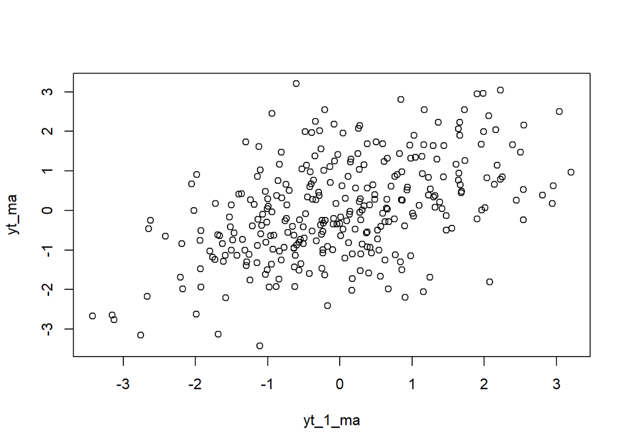

```r
plot(y=yt_ma,x=yt_1_ma)
```

```r
cor(yt_ma,yt_1_ma)
```

```
## [1] 0.4812534
```

```r
#Yt
yt_ma2 <- ma[-c(1,2)]
yt_ma2
```

```
##   [1] -1.2915620329 -1.3015948799  1.7351926068  1.2562788568  0.5420682960
##   [6] -1.0027522032  0.0455317307 -0.4772123823  1.9910489964  1.9896849554
##  [11]  2.9592939874  0.6274382561 -1.2542519075 -1.1064519824 -3.4259027876
##  [16] -2.6702081443 -2.1772598343 -1.9861737339 -2.6256484014 -0.2506699113
##  [21] -0.6026656155  3.2031114027  0.9706535444  1.6468681019  0.9395637722
##  [26]  0.5932560689 -0.0726194407  1.2487531452 -1.6874269623 -0.6176209397
##  [31] -1.1359621756 -0.2292622776 -0.3224219002 -0.7697074251 -0.9383012926
##  [36] -0.0388244474 -0.3398652534  2.2529335638  0.8528729667  0.2692343578
##  [41]  0.2166905557  0.5705335244 -0.3984528099  0.6760583981 -0.2820924818
##  [46]  2.0133111506  0.0704816091 -1.2108088641 -0.3858233765 -0.5245111947
##  [51]  1.0459147593  1.3451629886  1.2947874820  1.6426166974  0.7663716670
##  [56]  0.8645058603  0.2521133726  1.4401773026  1.6417561109  2.0642858034
##  [61]  2.3976502479  1.6626357876  2.2267088355  0.7941777120  0.9024398131
##  [66] -2.1907846412 -0.8432159110 -1.7305392767 -1.2358974650  0.2723339928
##  [71]  1.0309009367  1.9033543294 -0.2192564424  1.0104531628 -0.0759177586
```

[output cut: 45 more lines]

```r
#Yt-2
yt_2_ma <- ma[-c(299,300)]
yt_2_ma
```

```
##   [1] -1.0291204016 -1.6155257834 -1.2915620329 -1.3015948799  1.7351926068
##   [6]  1.2562788568  0.5420682960 -1.0027522032  0.0455317307 -0.4772123823
##  [11]  1.9910489964  1.9896849554  2.9592939874  0.6274382561 -1.2542519075
##  [16] -1.1064519824 -3.4259027876 -2.6702081443 -2.1772598343 -1.9861737339
##  [21] -2.6256484014 -0.2506699113 -0.6026656155  3.2031114027  0.9706535444
##  [26]  1.6468681019  0.9395637722  0.5932560689 -0.0726194407  1.2487531452
##  [31] -1.6874269623 -0.6176209397 -1.1359621756 -0.2292622776 -0.3224219002
##  [36] -0.7697074251 -0.9383012926 -0.0388244474 -0.3398652534  2.2529335638
##  [41]  0.8528729667  0.2692343578  0.2166905557  0.5705335244 -0.3984528099
##  [46]  0.6760583981 -0.2820924818  2.0133111506  0.0704816091 -1.2108088641
##  [51] -0.3858233765 -0.5245111947  1.0459147593  1.3451629886  1.2947874820
##  [56]  1.6426166974  0.7663716670  0.8645058603  0.2521133726  1.4401773026
##  [61]  1.6417561109  2.0642858034  2.3976502479  1.6626357876  2.2267088355
##  [66]  0.7941777120  0.9024398131 -2.1907846412 -0.8432159110 -1.7305392767
##  [71] -1.2358974650  0.2723339928  1.0309009367  1.9033543294 -0.2192564424
```

[output cut: 45 more lines]

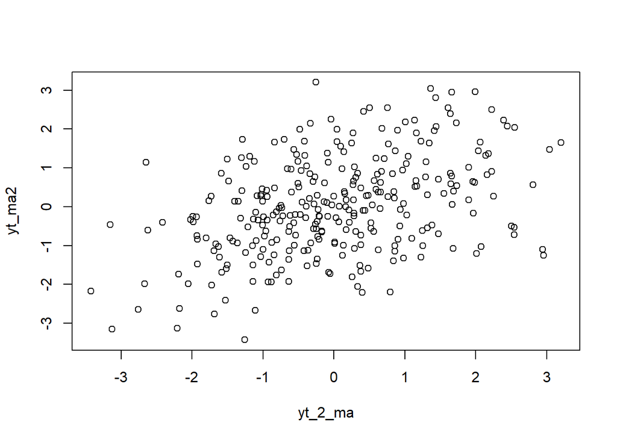

```r
plot(y=yt_ma2,x=yt_2_ma)
```

```r
cor(yt_ma2,yt_2_ma)
```

```
## [1] 0.4224952
```

```r
#Yt
yt_ma3 <- ma[-c(1,2,3)]
yt_ma3
```

```
##   [1] -1.3015948799  1.7351926068  1.2562788568  0.5420682960 -1.0027522032
##   [6]  0.0455317307 -0.4772123823  1.9910489964  1.9896849554  2.9592939874
##  [11]  0.6274382561 -1.2542519075 -1.1064519824 -3.4259027876 -2.6702081443
##  [16] -2.1772598343 -1.9861737339 -2.6256484014 -0.2506699113 -0.6026656155
##  [21]  3.2031114027  0.9706535444  1.6468681019  0.9395637722  0.5932560689
##  [26] -0.0726194407  1.2487531452 -1.6874269623 -0.6176209397 -1.1359621756
##  [31] -0.2292622776 -0.3224219002 -0.7697074251 -0.9383012926 -0.0388244474
##  [36] -0.3398652534  2.2529335638  0.8528729667  0.2692343578  0.2166905557
##  [41]  0.5705335244 -0.3984528099  0.6760583981 -0.2820924818  2.0133111506
##  [46]  0.0704816091 -1.2108088641 -0.3858233765 -0.5245111947  1.0459147593
##  [51]  1.3451629886  1.2947874820  1.6426166974  0.7663716670  0.8645058603
##  [56]  0.2521133726  1.4401773026  1.6417561109  2.0642858034  2.3976502479
##  [61]  1.6626357876  2.2267088355  0.7941777120  0.9024398131 -2.1907846412
##  [66] -0.8432159110 -1.7305392767 -1.2358974650  0.2723339928  1.0309009367
##  [71]  1.9033543294 -0.2192564424  1.0104531628 -0.0759177586  2.1804546068
```

[output cut: 45 more lines]

```r
#Yt-2
yt_3_ma <- ma[-c(298,299,300)]
yt_3_ma
```

```
##   [1] -1.0291204016 -1.6155257834 -1.2915620329 -1.3015948799  1.7351926068
##   [6]  1.2562788568  0.5420682960 -1.0027522032  0.0455317307 -0.4772123823
##  [11]  1.9910489964  1.9896849554  2.9592939874  0.6274382561 -1.2542519075
##  [16] -1.1064519824 -3.4259027876 -2.6702081443 -2.1772598343 -1.9861737339
##  [21] -2.6256484014 -0.2506699113 -0.6026656155  3.2031114027  0.9706535444
##  [26]  1.6468681019  0.9395637722  0.5932560689 -0.0726194407  1.2487531452
##  [31] -1.6874269623 -0.6176209397 -1.1359621756 -0.2292622776 -0.3224219002
##  [36] -0.7697074251 -0.9383012926 -0.0388244474 -0.3398652534  2.2529335638
##  [41]  0.8528729667  0.2692343578  0.2166905557  0.5705335244 -0.3984528099
##  [46]  0.6760583981 -0.2820924818  2.0133111506  0.0704816091 -1.2108088641
##  [51] -0.3858233765 -0.5245111947  1.0459147593  1.3451629886  1.2947874820
##  [56]  1.6426166974  0.7663716670  0.8645058603  0.2521133726  1.4401773026
##  [61]  1.6417561109  2.0642858034  2.3976502479  1.6626357876  2.2267088355
##  [66]  0.7941777120  0.9024398131 -2.1907846412 -0.8432159110 -1.7305392767
##  [71] -1.2358974650  0.2723339928  1.0309009367  1.9033543294 -0.2192564424
```

[output cut: 45 more lines]

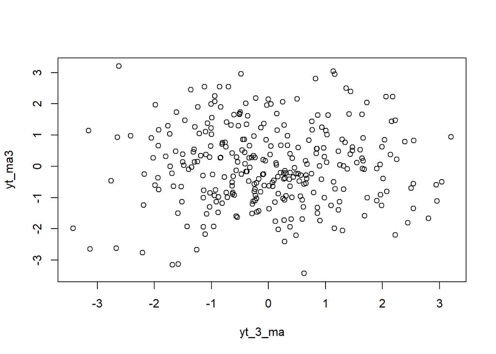

```r
plot(y=yt_ma3,x=yt_3_ma)
```

```r
cor(yt_ma3,yt_3_ma)
```

```
## [1] 0.007901504
```

##Pembangkitan Data AR(2) dengan phi 1 = 0.5 dan phi 2 = 0.2 secara manual

```r
set.seed(095)
n<-length(wn)
n
```

```
## [1] 300
```

```r
ar <- c(1:n)
for (i in 3:n) {ar[i]<-wn[i]+0.5*ar[i-1]+0.2*ar[i-2]}
ar
```

```
##   [1]  1.000000000  2.000000000  1.172120521  0.664932642  2.447261767
##   [6]  2.053424303  0.651287240 -0.338556951  0.955391235  0.179938199
##  [11]  1.767467397  2.452865890  3.034110561  1.133506329 -0.603538261
##  [16]  0.053798846 -2.504989579 -3.024790651 -2.030722014 -2.529727983
##  [21] -3.922495994 -1.271623157 -1.150312008  1.548288998  0.401628527
##  [26]  0.787659813  1.388316426  0.912969269  0.088520353  1.697090746
##  [31] -1.021895665 -0.916034609 -0.367669578 -0.267491777 -0.746357794
##  [36] -1.040483442 -1.038845302 -0.250327264 -0.642075562  1.719172232
##  [41]  0.933419506 -0.255286124  0.580714423  1.240662271 -0.375527854
##  [46]  0.580410304  0.392191513  1.942627129  0.361798593 -1.344472419
##  [51]  0.192630954  0.134245105  0.553329391  1.285509979  1.386801456
##  [56]  1.750569428  1.218961637  1.317533889  0.971706992  1.947114978
##  [61]  2.289064485  2.431121980  3.039458079  2.583855501  3.075716860
##  [66]  2.031707006  1.837067202 -0.934584255 -0.162953092 -0.618027358
##  [71] -1.399803535  0.081886825  1.064645559  1.387352894 -0.430309695
```

[output cut: 45 more lines]

##Pembangkitan Data AR(2) dengan phi 1 = 0.5 dan phi 2 = 0.2 secara arima.sim

```r
ar1 <- arima.sim(list(order=c(2,0,0), ar=c(0.5,0.2)), n=300)
ar1
```

```
## Time Series:
## Start = 1
## End = 300
## Frequency = 1
##   [1]  0.782509402  1.384390023  0.909975985  0.086238431  1.695351128
##   [6] -1.023221858 -0.917045629 -0.368440326 -0.268079355 -0.746805733
##  [11] -1.040824927 -1.039105633 -0.250525726 -0.642226860  1.719056891
##  [16]  0.933331576 -0.255353157  0.580663320  1.240623314 -0.375557553
##  [21]  0.580387663  0.392174253  1.942613971  0.361788561 -1.344480067
##  [26]  0.192625124  0.134240661  0.553326003  1.285507396  1.386799487
##  [31]  1.750567927  1.218960493  1.317533017  0.971706327  1.947114471
##  [36]  2.289064098  2.431121685  3.039457855  2.583855330  3.075716730
##  [41]  2.031706906  1.837067126 -0.934584313 -0.162953136 -0.618027391
##  [46] -1.399803561  0.081886806  1.064645545  1.387352883 -0.430309704
##  [51]  1.104343340  0.775530077  2.040103605  1.557272255  1.541719229
```

[output cut: 49 more lines]

### Plot Time Series

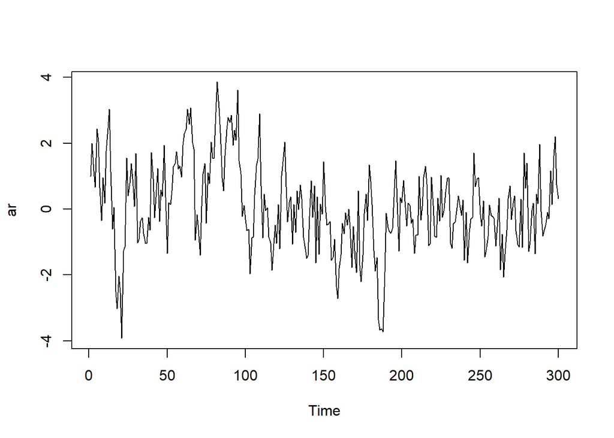

```r
ts.plot(ar)
```

Berdasarkan plot time series tersebut terlihat bahwa data cenderung stasioner pada rataan

### Plot ACF

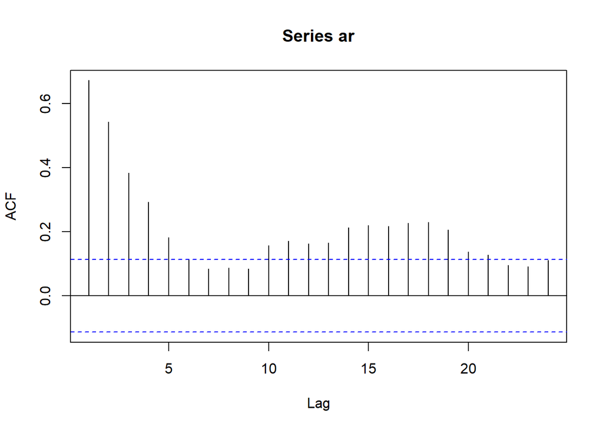

```r
acf(ar)
```

Berdasarkan plot ACF tersebut terlihat bahwa plot ACF cenderung *tails off* dan cenderung membentuk pola grafik sinus

### Plot PACF

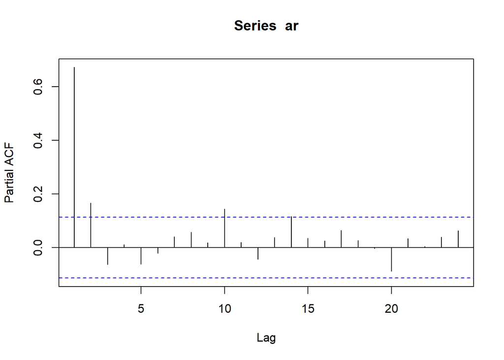

```r
pacf(ar)
```

### Plot EACF

```r
TSA::eacf(ar)
```

```
## AR/MA
##   0 1 2 3 4 5 6 7 8 9 10 11 12 13
## 0 x x x x x o o o o x x  x  x  x
## 1 x x o o o o o o o o o  o  o  o
## 2 x o o o o o o o o o o  o  o  o
## 3 x o o o o o o o o o o  o  o  o
## 4 x x x o o o o o o o o  o  o  o
## 5 x x x o o o o o x o o  o  o  o
## 6 x x o o o o o o o o o  o  o  o
## 7 x x o o x o o o x o o  o  o  o
```

### Scatterplot Antar Lag

#### Korelasi antara $Y_t$ dengan $Y_{t-1}$

```r
#Yt
yt_ar <- ar[-1]
yt_ar
```

```
##   [1]  2.000000000  1.172120521  0.664932642  2.447261767  2.053424303
##   [6]  0.651287240 -0.338556951  0.955391235  0.179938199  1.767467397
##  [11]  2.452865890  3.034110561  1.133506329 -0.603538261  0.053798846
##  [16] -2.504989579 -3.024790651 -2.030722014 -2.529727983 -3.922495994
##  [21] -1.271623157 -1.150312008  1.548288998  0.401628527  0.787659813
##  [26]  1.388316426  0.912969269  0.088520353  1.697090746 -1.021895665
##  [31] -0.916034609 -0.367669578 -0.267491777 -0.746357794 -1.040483442
##  [36] -1.038845302 -0.250327264 -0.642075562  1.719172232  0.933419506
##  [41] -0.255286124  0.580714423  1.240662271 -0.375527854  0.580410304
##  [46]  0.392191513  1.942627129  0.361798593 -1.344472419  0.192630954
##  [51]  0.134245105  0.553329391  1.285509979  1.386801456  1.750569428
##  [56]  1.218961637  1.317533889  0.971706992  1.947114978  2.289064485
##  [61]  2.431121980  3.039458079  2.583855501  3.075716860  2.031707006
##  [66]  1.837067202 -0.934584255 -0.162953092 -0.618027358 -1.399803535
##  [71]  0.081886825  1.064645559  1.387352894 -0.430309695  1.104343346
```

[output cut: 45 more lines]

```r
#Yt-1
yt_1_ar <- ar[-300]
yt_1_ar
```

```
##   [1]  1.000000000  2.000000000  1.172120521  0.664932642  2.447261767
##   [6]  2.053424303  0.651287240 -0.338556951  0.955391235  0.179938199
##  [11]  1.767467397  2.452865890  3.034110561  1.133506329 -0.603538261
##  [16]  0.053798846 -2.504989579 -3.024790651 -2.030722014 -2.529727983
##  [21] -3.922495994 -1.271623157 -1.150312008  1.548288998  0.401628527
##  [26]  0.787659813  1.388316426  0.912969269  0.088520353  1.697090746
##  [31] -1.021895665 -0.916034609 -0.367669578 -0.267491777 -0.746357794
##  [36] -1.040483442 -1.038845302 -0.250327264 -0.642075562  1.719172232
##  [41]  0.933419506 -0.255286124  0.580714423  1.240662271 -0.375527854
##  [46]  0.580410304  0.392191513  1.942627129  0.361798593 -1.344472419
##  [51]  0.192630954  0.134245105  0.553329391  1.285509979  1.386801456
##  [56]  1.750569428  1.218961637  1.317533889  0.971706992  1.947114978
##  [61]  2.289064485  2.431121980  3.039458079  2.583855501  3.075716860
##  [66]  2.031707006  1.837067202 -0.934584255 -0.162953092 -0.618027358
##  [71] -1.399803535  0.081886825  1.064645559  1.387352894 -0.430309695
```

[output cut: 45 more lines]

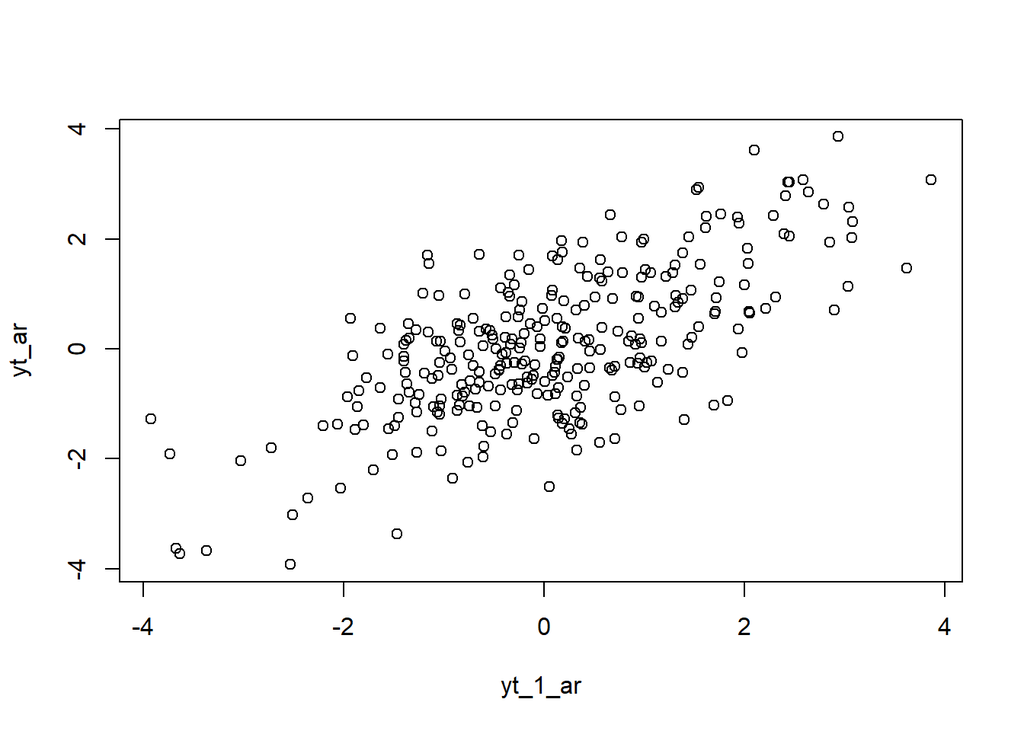

```r
plot(y=yt_ar,x=yt_1_ar)
```

Berdasarkan scatterplot tersebut, terlihat bahwa terdapat hubungan positif antara $Y_t$ dengan $Y_{t-1}$.

```r
cor(yt_ar,yt_1_ar)
```

```
## [1] 0.6731122
```

#### Korelasi antara $Y_t$ dengan $Y_{t-2}$

```r
#Yt
yt_ar2 <- ar[-c(1,2)]
yt_ar2
```

```
##   [1]  1.172120521  0.664932642  2.447261767  2.053424303  0.651287240
##   [6] -0.338556951  0.955391235  0.179938199  1.767467397  2.452865890
##  [11]  3.034110561  1.133506329 -0.603538261  0.053798846 -2.504989579
##  [16] -3.024790651 -2.030722014 -2.529727983 -3.922495994 -1.271623157
##  [21] -1.150312008  1.548288998  0.401628527  0.787659813  1.388316426
##  [26]  0.912969269  0.088520353  1.697090746 -1.021895665 -0.916034609
##  [31] -0.367669578 -0.267491777 -0.746357794 -1.040483442 -1.038845302
##  [36] -0.250327264 -0.642075562  1.719172232  0.933419506 -0.255286124
##  [41]  0.580714423  1.240662271 -0.375527854  0.580410304  0.392191513
##  [46]  1.942627129  0.361798593 -1.344472419  0.192630954  0.134245105
##  [51]  0.553329391  1.285509979  1.386801456  1.750569428  1.218961637
##  [56]  1.317533889  0.971706992  1.947114978  2.289064485  2.431121980
##  [61]  3.039458079  2.583855501  3.075716860  2.031707006  1.837067202
##  [66] -0.934584255 -0.162953092 -0.618027358 -1.399803535  0.081886825
##  [71]  1.064645559  1.387352894 -0.430309695  1.104343346  0.775530082
```

[output cut: 45 more lines]

```r
#Yt-2
yt_2_ar <- ar[-c(299,300)]
yt_2_ar
```

```
##   [1]  1.000000000  2.000000000  1.172120521  0.664932642  2.447261767
##   [6]  2.053424303  0.651287240 -0.338556951  0.955391235  0.179938199
##  [11]  1.767467397  2.452865890  3.034110561  1.133506329 -0.603538261
##  [16]  0.053798846 -2.504989579 -3.024790651 -2.030722014 -2.529727983
##  [21] -3.922495994 -1.271623157 -1.150312008  1.548288998  0.401628527
##  [26]  0.787659813  1.388316426  0.912969269  0.088520353  1.697090746
##  [31] -1.021895665 -0.916034609 -0.367669578 -0.267491777 -0.746357794
##  [36] -1.040483442 -1.038845302 -0.250327264 -0.642075562  1.719172232
##  [41]  0.933419506 -0.255286124  0.580714423  1.240662271 -0.375527854
##  [46]  0.580410304  0.392191513  1.942627129  0.361798593 -1.344472419
##  [51]  0.192630954  0.134245105  0.553329391  1.285509979  1.386801456
##  [56]  1.750569428  1.218961637  1.317533889  0.971706992  1.947114978
##  [61]  2.289064485  2.431121980  3.039458079  2.583855501  3.075716860
##  [66]  2.031707006  1.837067202 -0.934584255 -0.162953092 -0.618027358
##  [71] -1.399803535  0.081886825  1.064645559  1.387352894 -0.430309695
```

[output cut: 45 more lines]

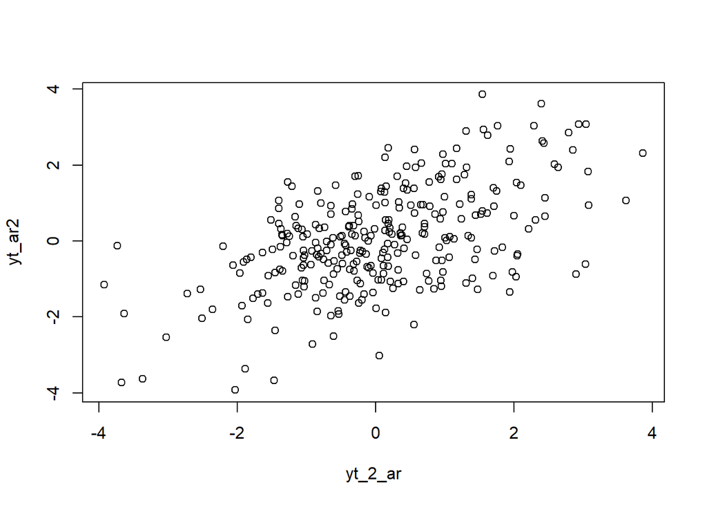

```r
plot(y=yt_ar2,x=yt_2_ar)
```

Berdasarkan scatterplot tersebut, terlihat bahwa terdapat hubungan positif antara $Y_t$ dengan $Y_{t-2}$.

```r
cor(yt_ar2,yt_2_ar)
```

```
## [1] 0.5463056
```

```r
#Yt
yt_ar3 <- ar[-c(1,2,3)]
yt_ar3
```

```
##   [1]  0.664932642  2.447261767  2.053424303  0.651287240 -0.338556951
##   [6]  0.955391235  0.179938199  1.767467397  2.452865890  3.034110561
##  [11]  1.133506329 -0.603538261  0.053798846 -2.504989579 -3.024790651
##  [16] -2.030722014 -2.529727983 -3.922495994 -1.271623157 -1.150312008
##  [21]  1.548288998  0.401628527  0.787659813  1.388316426  0.912969269
##  [26]  0.088520353  1.697090746 -1.021895665 -0.916034609 -0.367669578
##  [31] -0.267491777 -0.746357794 -1.040483442 -1.038845302 -0.250327264
##  [36] -0.642075562  1.719172232  0.933419506 -0.255286124  0.580714423
##  [41]  1.240662271 -0.375527854  0.580410304  0.392191513  1.942627129
##  [46]  0.361798593 -1.344472419  0.192630954  0.134245105  0.553329391
##  [51]  1.285509979  1.386801456  1.750569428  1.218961637  1.317533889
##  [56]  0.971706992  1.947114978  2.289064485  2.431121980  3.039458079
##  [61]  2.583855501  3.075716860  2.031707006  1.837067202 -0.934584255
##  [66] -0.162953092 -0.618027358 -1.399803535  0.081886825  1.064645559
##  [71]  1.387352894 -0.430309695  1.104343346  0.775530082  2.040103609
```

[output cut: 45 more lines]

```r
#Yt-2
yt_3_ar <- ar[-c(298,299,300)]
yt_3_ar
```

```
##   [1]  1.000000000  2.000000000  1.172120521  0.664932642  2.447261767
##   [6]  2.053424303  0.651287240 -0.338556951  0.955391235  0.179938199
##  [11]  1.767467397  2.452865890  3.034110561  1.133506329 -0.603538261
##  [16]  0.053798846 -2.504989579 -3.024790651 -2.030722014 -2.529727983
##  [21] -3.922495994 -1.271623157 -1.150312008  1.548288998  0.401628527
##  [26]  0.787659813  1.388316426  0.912969269  0.088520353  1.697090746
##  [31] -1.021895665 -0.916034609 -0.367669578 -0.267491777 -0.746357794
##  [36] -1.040483442 -1.038845302 -0.250327264 -0.642075562  1.719172232
##  [41]  0.933419506 -0.255286124  0.580714423  1.240662271 -0.375527854
##  [46]  0.580410304  0.392191513  1.942627129  0.361798593 -1.344472419
##  [51]  0.192630954  0.134245105  0.553329391  1.285509979  1.386801456
##  [56]  1.750569428  1.218961637  1.317533889  0.971706992  1.947114978
##  [61]  2.289064485  2.431121980  3.039458079  2.583855501  3.075716860
##  [66]  2.031707006  1.837067202 -0.934584255 -0.162953092 -0.618027358
##  [71] -1.399803535  0.081886825  1.064645559  1.387352894 -0.430309695
```

[output cut: 45 more lines]

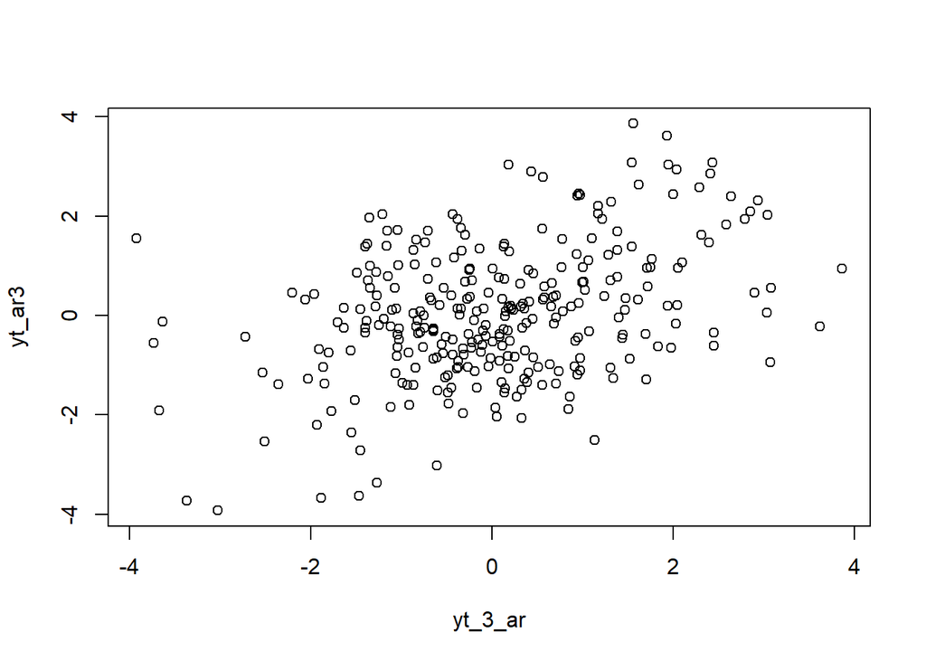

```r
plot(y=yt_ar3,x=yt_3_ar)
```

## Fungsi pembangkitan ARMA

Setelah mengetahui cara membangkitkan data berpola AR, MA, dan ARMA sederhana, bagaimana cara melakukan pembangkitan data berpola tersebut yang lebih kompleks? Apakah dapat dibuat suatu fungsi yang fleksibel yang memungkinan pembangkitan dengan berapapun jumlah koefisien?

Pertama, lihat kembali bentuk umum data berpola ARMA.

$$y_{t} = c + \sum_{i=1}^p \phi_{i}y_{t-i} + \sum_{j=1}^q e_{t-j}+ e_{t}$$

Komponen $c$ dan $e_{t}$ cukup mudah untuk dibuat dan dicari. Bagaimana untuk komponen AR dan MA? Bayangkan ada koefisien dan data sebagai berikut:

$$\begin{aligned}
\begin{bmatrix}
\phi_1 \ \phi_2 \ \phi_3
\end{bmatrix}&=
\begin{bmatrix}
0.3 \ 0.5 \ 0.2
\end{bmatrix}
\\
\begin{bmatrix}
y_{t-1} \ y_{t-2} \ y_{t-3}
\end{bmatrix}&=
\begin{bmatrix}
1 \ 2 \ 3
\end{bmatrix}
\end{aligned}$$

Maka dari itu,

$$\begin{aligned}
\begin{bmatrix}
\phi_1 \ \phi_2 \ \phi_3
\end{bmatrix}
\begin{bmatrix}
y_{t-1} \\ y_{t-2} \\ y_{t-3}
\end{bmatrix} &= \phi_1 \ y_{t-1}+\phi_2 \ y_{t-2}+\phi_3 \ y_{t-3}
\\
\begin{bmatrix}
0.3 \ 0.5 \ 0.2
\end{bmatrix}
\begin{bmatrix}
1 \\ 2 \\ 3
\end{bmatrix} & = 0.3 \cdot1+0.5 \cdot 2+0.2 \cdot 3\\
&=0.3+1+0.6 = 1.9
\end{aligned}$$

Jika koefisien dan *white noise*/nilai deret waktu sebelumnya dapat diekstrak dalam bentuk vektor, dapat dilakukan perkalian matriks untuk mencari nilai bagian AR dan MA:

```r
set.seed(095)
coefs <- c(0.5, 0.2)
e <- c(1, 2)
```

```r
coefs * e
```

```
## [1] 0.5 0.4
```

```r
sum(coefs * e)
```

```
## [1] 0.9
```

```r
arma.sim <- function(n, macoef, arcoef){
  manum <- length(macoef)
  arnum <- length(arcoef)
  stopifnot(manum < n & arnum < n)

  wn <- rnorm(n, sd = 0.5)
  init <- max(manum, arnum)

  arma <- wn[1:init]
  for(i in {init+1}:n){
   mastart <- i - manum
   maend <- i-1
   arstart <- i - arnum
   arend <- i-1
   arma[i] <- sum(arcoef * arma[arstart:arend]) + sum(macoef * wn[mastart:maend])  + wn[i]
   }
  return(arma)
}
```

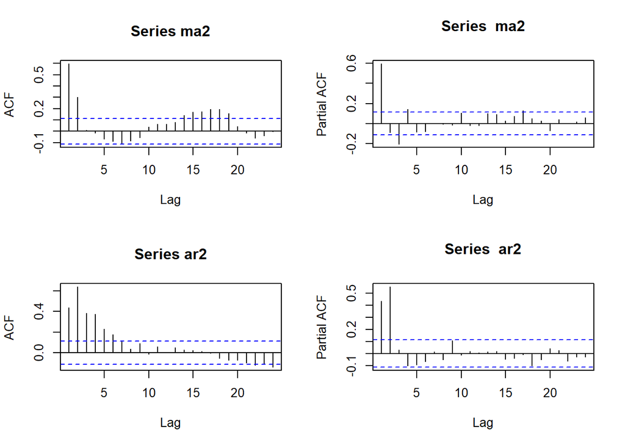

```r
# beberapa contoh pembangkitan melalui fungsi

ma2 <- arma.sim(300, c(0.4,0.6), 0)
ar2 <- arma.sim(300, 0, c(0.5, 0.2))

par(mfrow = c(2, 2))
acf(ma2)
pacf(ma2)
acf(ar2)
pacf(ar2)
```

```r
#contoh untuk ARMA
arma22 <- arma.sim(300, c(0.4, 0.6), c(0.5,0.2))

arma22 |> arima(c(2,0,2))
```

```
##
## Call:
## arima(x = arma22, order = c(2, 0, 2))
##
## Coefficients:
##          ar1     ar2     ma1     ma2  intercept
##       0.1680  0.5055  0.6455  0.4000    -0.1394
## s.e.  0.0831  0.0821  0.0816  0.0679     0.1718
##
## sigma^2 estimated as 0.2321:  log likelihood = -207.52,  aic = 425.05
```

```r
set.seed(095)
n = length(wn)
phi1 = 0.4
phi2 = 0.6
theta1 = 0.5
theta2 = 0.2

y.arma=c(1:n)
for (i in 3:n){y.arma[i] = phi1*y.arma[i-1] + phi2*y.arma[i-2]+theta1*wn[i-1]+theta2*wn[i-2]+wn[i]}
```

##Pembangkitan Data ARMA(2,2) dengan phi 1 = 0.5, phi 2 = 0.2, theta 1 = 0.4, theta 2 = 0.6 secara arima.sim

```r
arma22 <- arima.sim(list(order=c(2,0,2), ar = c(0.5, 0.2), ma = c(0.4, 0.6)),n=300)
arma22
```

```
## Time Series:
## Start = 1
## End = 300
## Frequency = 1
##   [1]  1.935042767  1.282238976  2.276881186 -0.292538574 -0.308513989
##   [6] -1.348726885 -0.965328518 -1.074831536 -1.500188897 -1.903362048
##  [11] -1.290543251 -1.365809288  1.311920269  1.235671244  1.149454033
##  [16]  1.038551821  1.319700242  0.469107675  1.174552284  0.399005195
##  [21]  2.447724205  1.374144751 -0.034191648 -0.128090250 -0.595394649
##  [26]  0.722599385  1.587383751  2.232999234  3.076593065  2.751268046
##  [31]  2.855458496  2.230096230  3.126317117  3.650933915  4.515016184
##  [36]  5.385345123  5.258311586  5.932933653  4.812306856  4.495179972
##  [41]  1.019266716  0.565453441 -1.243959213 -1.744786383 -0.848851041
##  [46]  0.257518139  1.862343191  0.763418781  1.764631191  0.959081593
##  [51]  3.012921642  2.838631745  3.388690296  4.490438413  5.963410134
```

[output cut: 49 more lines]

## Karakteristik ARMA(2,2)

### Plot Time Series

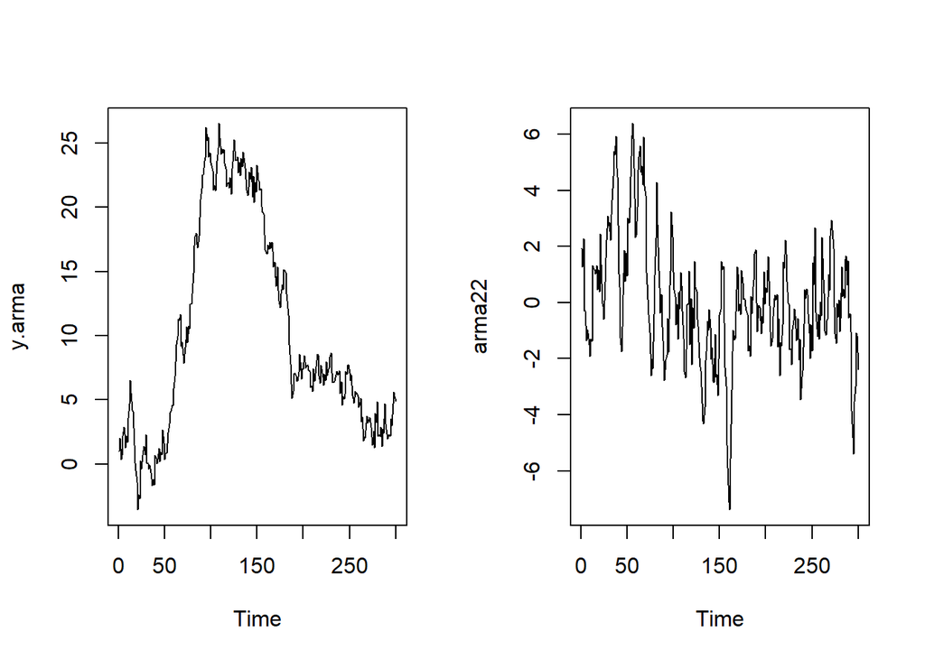

```r
par(mfrow = c(1, 2))
ts.plot(y.arma)
ts.plot(arma22)
```

```r
par(mfrow = c(1, 1))
```

### Plot ACF

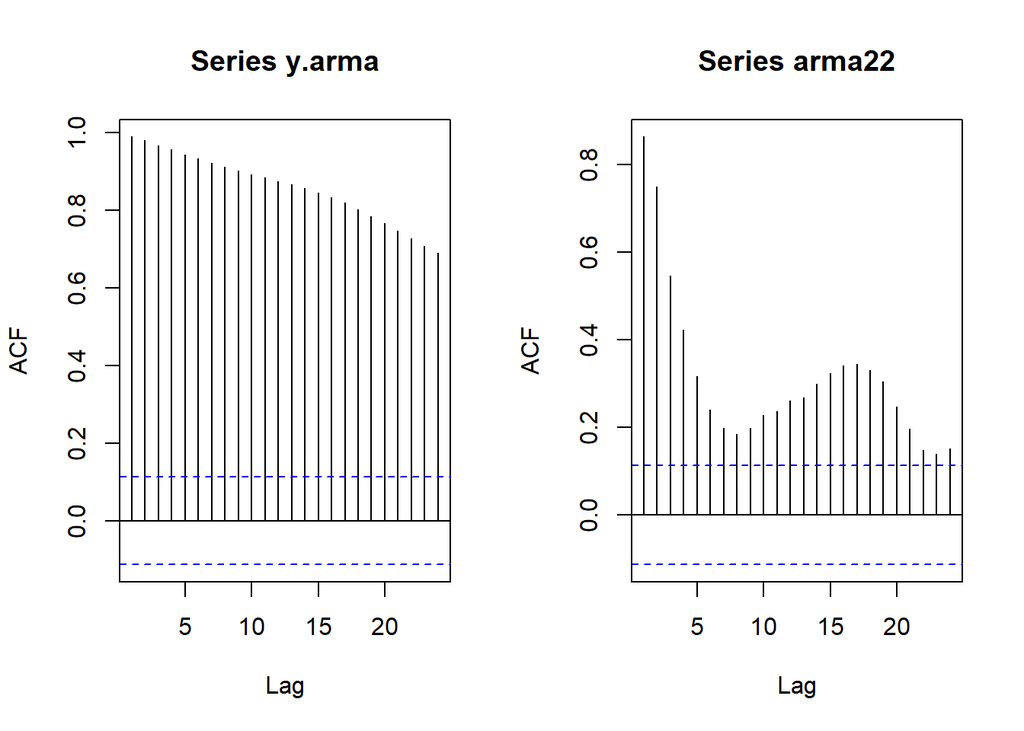

```r
par(mfrow = c(1, 2))
acf(y.arma)
acf(arma22)
```

```r
par(mfrow = c(1, 1))
```

### Plot PACF

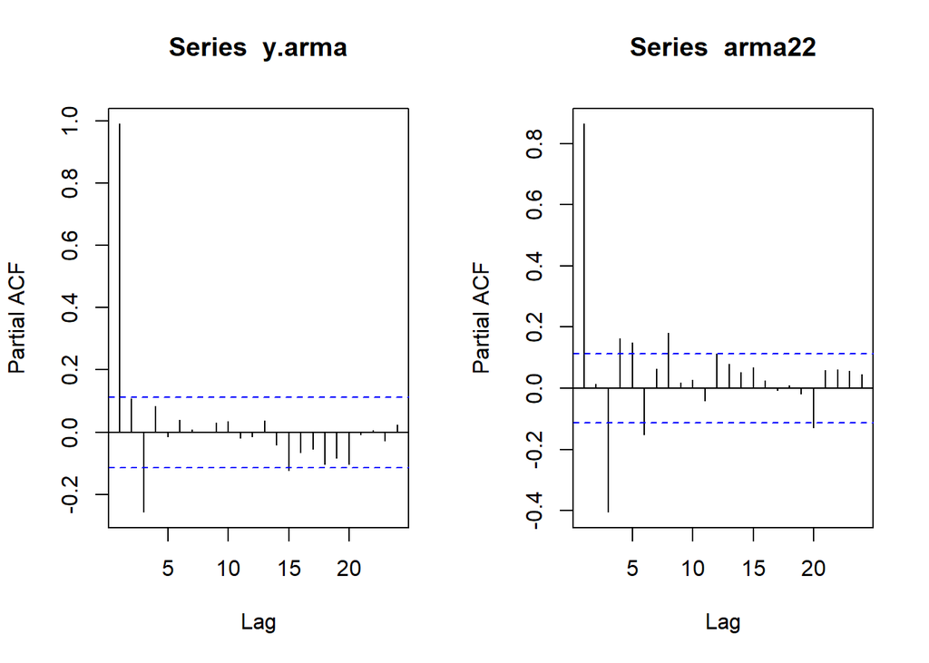

```r
par(mfrow = c(1, 2))
pacf(y.arma)
pacf(arma22)
```

```r
par(mfrow = c(1, 1))
```

### Plot EACF

```r
TSA::eacf(y.arma)
```

```
## AR/MA
##   0 1 2 3 4 5 6 7 8 9 10 11 12 13
## 0 x x x x x x x x x x x  x  x  x
## 1 o x x x o o o o o o o  o  o  o
## 2 x x o o o o o o o o o  o  o  o
## 3 x x o o o o o o o o o  o  o  o
## 4 x o o o o o o o o o o  o  o  o
## 5 o o x o o o o o o o o  o  o  o
## 6 o x x o x o o o o o o  o  o  o
## 7 x x x o x o o o o o o  o  o  o
```

```r
TSA::eacf(arma22)
```

```
## AR/MA
##   0 1 2 3 4 5 6 7 8 9 10 11 12 13
## 0 x x x x x x x x x x x  x  x  x
## 1 o x x o o o o o o o o  o  o  o
## 2 o x o o o o o o o o o  o  o  o
## 3 x x x o o o o o o o o  o  o  o
## 4 x x o o o x o o o o o  o  o  o
## 5 x x x x o o o o o o o  o  o  o
## 6 x x x x o o o o o o o  o  o  o
## 7 x x x o o o x x o o o  o  o  o
```

Berdasarkan pola segitiga nol pada plot EACF, terlihat bahwa segitiga nol berada pada ordo AR(2) dan ordo MA(2)

### Scatterplot Antar Lag

#### Korelasi antara $Y_t$ dengan $Y_{t-1}$

```r
#Yt
yt_arma <- arma22[-1]
yt_arma
```

```
##   [1]  1.282238976  2.276881186 -0.292538574 -0.308513989 -1.348726885
##   [6] -0.965328518 -1.074831536 -1.500188897 -1.903362048 -1.290543251
##  [11] -1.365809288  1.311920269  1.235671244  1.149454033  1.038551821
##  [16]  1.319700242  0.469107675  1.174552284  0.399005195  2.447724205
##  [21]  1.374144751 -0.034191648 -0.128090250 -0.595394649  0.722599385
##  [26]  1.587383751  2.232999234  3.076593065  2.751268046  2.855458496
##  [31]  2.230096230  3.126317117  3.650933915  4.515016184  5.385345123
##  [36]  5.258311586  5.932933653  4.812306856  4.495179972  1.019266716
##  [41]  0.565453441 -1.243959213 -1.744786383 -0.848851041  0.257518139
##  [46]  1.862343191  0.763418781  1.764631191  0.959081593  3.012921642
##  [51]  2.838631745  3.388690296  4.490438413  5.963410134  6.385395736
##  [56]  5.860342321  3.715553670  2.327302222  2.408581443  3.398753624
##  [61]  4.728004386  5.202461403  5.584380811  4.659701661  4.883322834
##  [66]  4.220560829  5.898995995  4.176539362  3.829317184  1.082450499
##  [71]  0.669994364 -0.407028467 -0.704482065 -1.058177738 -2.593908575
```

[output cut: 45 more lines]

```r
#Yt-1
yt_1_arma <- arma22[-300]
yt_1_arma
```

```
##   [1]  1.935042767  1.282238976  2.276881186 -0.292538574 -0.308513989
##   [6] -1.348726885 -0.965328518 -1.074831536 -1.500188897 -1.903362048
##  [11] -1.290543251 -1.365809288  1.311920269  1.235671244  1.149454033
##  [16]  1.038551821  1.319700242  0.469107675  1.174552284  0.399005195
##  [21]  2.447724205  1.374144751 -0.034191648 -0.128090250 -0.595394649
##  [26]  0.722599385  1.587383751  2.232999234  3.076593065  2.751268046
##  [31]  2.855458496  2.230096230  3.126317117  3.650933915  4.515016184
##  [36]  5.385345123  5.258311586  5.932933653  4.812306856  4.495179972
##  [41]  1.019266716  0.565453441 -1.243959213 -1.744786383 -0.848851041
##  [46]  0.257518139  1.862343191  0.763418781  1.764631191  0.959081593
##  [51]  3.012921642  2.838631745  3.388690296  4.490438413  5.963410134
##  [56]  6.385395736  5.860342321  3.715553670  2.327302222  2.408581443
##  [61]  3.398753624  4.728004386  5.202461403  5.584380811  4.659701661
##  [66]  4.883322834  4.220560829  5.898995995  4.176539362  3.829317184
##  [71]  1.082450499  0.669994364 -0.407028467 -0.704482065 -1.058177738
```

[output cut: 45 more lines]

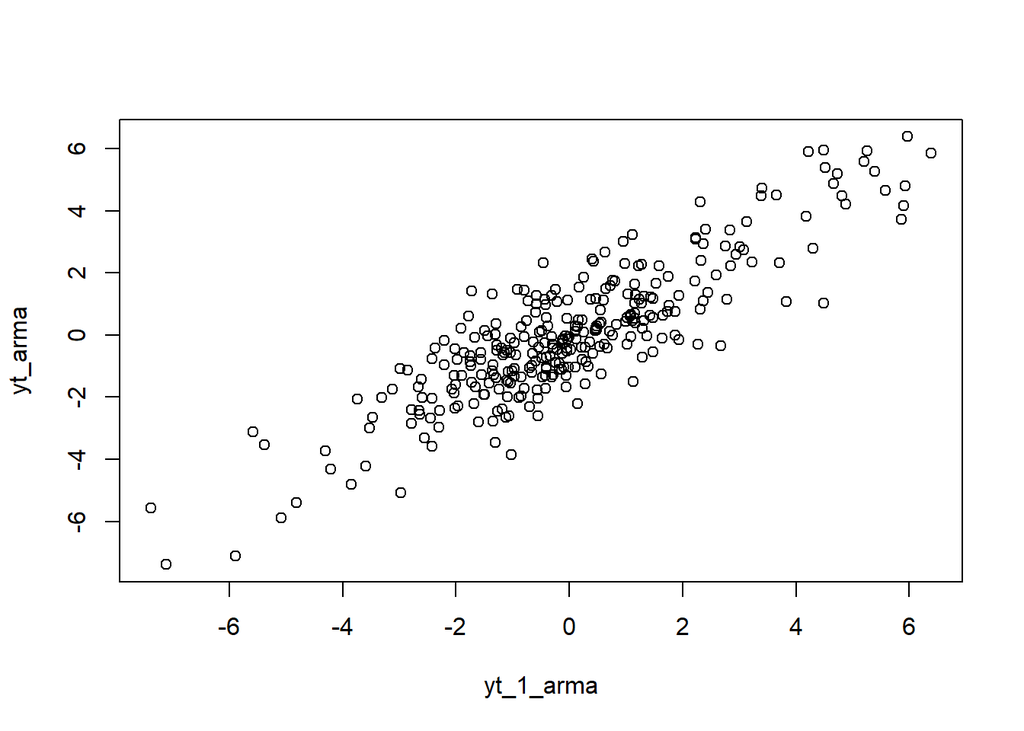

```r
plot(y=yt_arma,x=yt_1_arma)
```

Berdasarkan scatterplot tersebut, terlihat bahwa terdapat hubungan positif antara $Y_t$ dengan $Y_{t-1}$.

```r
cor(yt_arma,yt_1_arma)
```

```
## [1] 0.8663816
```

```r
#Yt
yt_arma <- arma22[c(-1,-2)]
#Yt-1
yt_2_arma <- arma22[c(-299,-300)]
```

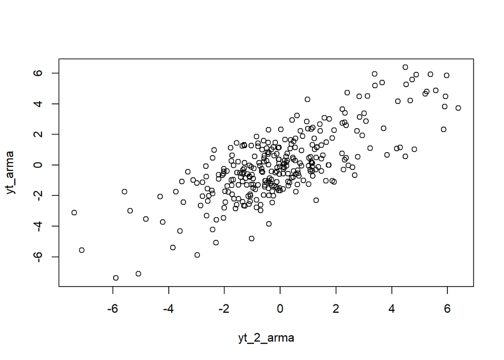

```r
plot(y=yt_arma,x=yt_2_arma)
```

Berdasarkan scatterplot tersebut, terlihat bahwa terdapat hubungan positif antara $Y_t$ dengan $Y_{t-2}$.

```r
cor(yt_arma,yt_2_arma)
```

```
## [1] 0.7522851
```

```r
#Yt
yt_arma <- arma22[c(-1,-2,-3)]
yt_arma
```

```
##   [1] -0.292538574 -0.308513989 -1.348726885 -0.965328518 -1.074831536
##   [6] -1.500188897 -1.903362048 -1.290543251 -1.365809288  1.311920269
##  [11]  1.235671244  1.149454033  1.038551821  1.319700242  0.469107675
##  [16]  1.174552284  0.399005195  2.447724205  1.374144751 -0.034191648
##  [21] -0.128090250 -0.595394649  0.722599385  1.587383751  2.232999234
##  [26]  3.076593065  2.751268046  2.855458496  2.230096230  3.126317117
##  [31]  3.650933915  4.515016184  5.385345123  5.258311586  5.932933653
##  [36]  4.812306856  4.495179972  1.019266716  0.565453441 -1.243959213
##  [41] -1.744786383 -0.848851041  0.257518139  1.862343191  0.763418781
##  [46]  1.764631191  0.959081593  3.012921642  2.838631745  3.388690296
##  [51]  4.490438413  5.963410134  6.385395736  5.860342321  3.715553670
##  [56]  2.327302222  2.408581443  3.398753624  4.728004386  5.202461403
##  [61]  5.584380811  4.659701661  4.883322834  4.220560829  5.898995995
##  [66]  4.176539362  3.829317184  1.082450499  0.669994364 -0.407028467
##  [71] -0.704482065 -1.058177738 -2.593908575 -2.013738120 -2.361400998
```

[output cut: 45 more lines]

```r
#Yt-1
yt_3_arma <- arma22[c(-298, -299,-300)]
yt_3_arma
```

```
##   [1]  1.935042767  1.282238976  2.276881186 -0.292538574 -0.308513989
##   [6] -1.348726885 -0.965328518 -1.074831536 -1.500188897 -1.903362048
##  [11] -1.290543251 -1.365809288  1.311920269  1.235671244  1.149454033
##  [16]  1.038551821  1.319700242  0.469107675  1.174552284  0.399005195
##  [21]  2.447724205  1.374144751 -0.034191648 -0.128090250 -0.595394649
##  [26]  0.722599385  1.587383751  2.232999234  3.076593065  2.751268046
##  [31]  2.855458496  2.230096230  3.126317117  3.650933915  4.515016184
##  [36]  5.385345123  5.258311586  5.932933653  4.812306856  4.495179972
##  [41]  1.019266716  0.565453441 -1.243959213 -1.744786383 -0.848851041
##  [46]  0.257518139  1.862343191  0.763418781  1.764631191  0.959081593
##  [51]  3.012921642  2.838631745  3.388690296  4.490438413  5.963410134
##  [56]  6.385395736  5.860342321  3.715553670  2.327302222  2.408581443
##  [61]  3.398753624  4.728004386  5.202461403  5.584380811  4.659701661
##  [66]  4.883322834  4.220560829  5.898995995  4.176539362  3.829317184
##  [71]  1.082450499  0.669994364 -0.407028467 -0.704482065 -1.058177738
```

[output cut: 45 more lines]

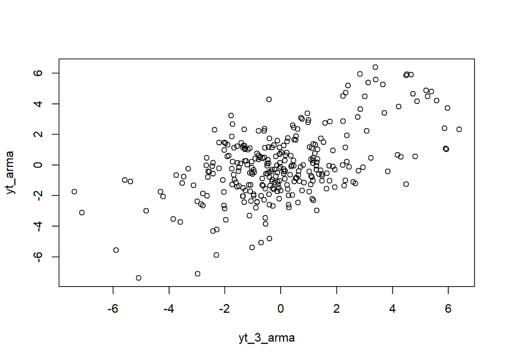

```r
plot(y=yt_arma,x=yt_3_arma)
```

Berdasarkan scatterplot tersebut, terlihat bahwa terdapat hubungan positif antara $Y_t$ dengan $Y_{t-3}$.

```r
cor(yt_arma,yt_3_arma)
```

```
## [1] 0.5504663
```